# ADA 442 HomeWork

Homework Number 1: Linear Regression

Furkan

11/8/2021

# Introduction

In Addition, comparison between Multiple Linear Regression Model and Simple Linear Regression Model over statistical facts has been made.

# Methodology

Since data set that chosen contains quantitative variables mainly, Linear Regression and Multiple Linear Regression have been used to create models.

*Skeleton Formula that has been used for Simple Linear Regression :* Y ~ B0 + B1x + ϵ *Skeleton Formula that has been used for Multiple Linear Regression :* Y ~ B0 + B1x1 + B2x2 + B3x3 + ϵ

At the evaluation phase; *R-squared*, *Adjusted R-squared*, *Residual Standard Error*, *p-value*, *F-statistics* values and *compare_performance()* method has been used.

# Data Set

```r
library(ISLR2)
data("Credit")
set.seed(73745) # for reproducible results
```

- I have used credit card balance data which contains information of 400 customers from ISLR2 library of R.
- Credit data frame has consisted of 11 variables which are ‘Income’, ‘Limit’, ‘Rating’, ‘Cards’, ‘Age’, ‘Education’, ‘Own’, ‘Student’, ‘Married’, ‘Region’, and ‘Balance’.
- There are 7 quantitative and 4 qualitative data on set.

# Explaratory Data analysis

*Superficial Sight of Data, Summary and Plot :*

```r
head(Credit)
```

|  | Income | Limit | Rating | Cards | Age | Education | Own | Student | Married | Region | Balance |
| --- | --- | --- | --- | --- | --- | --- | --- | --- | --- | --- | --- |
| 1 | 14.891 | 3606 | 283 | 2 | 34 | 11 | No | No | Yes | South | 333 |
| 2 | 106.025 | 6645 | 483 | 3 | 82 | 15 | Yes | Yes | Yes | West | 903 |
| 3 | 104.593 | 7075 | 514 | 4 | 71 | 11 | No | No | No | West | 580 |
| 4 | 148.924 | 9504 | 681 | 3 | 36 | 11 | Yes | No | No | West | 964 |
| 5 | 55.882 | 4897 | 357 | 2 | 68 | 16 | No | No | Yes | South | 331 |
| 6 | 80.180 | 8047 | 569 | 4 | 77 | 10 | No | No | No | South | 1151 |

```r
summary(Credit)
```

```
##      Income           Limit           Rating          Cards
##  Min.   : 10.35   Min.   :  855   Min.   : 93.0   Min.   :1.000
##  1st Qu.: 21.01   1st Qu.: 3088   1st Qu.:247.2   1st Qu.:2.000
##  Median : 33.12   Median : 4622   Median :344.0   Median :3.000
##  Mean   : 45.22   Mean   : 4736   Mean   :354.9   Mean   :2.958
##  3rd Qu.: 57.47   3rd Qu.: 5873   3rd Qu.:437.2   3rd Qu.:4.000
##  Max.   :186.63   Max.   :13913   Max.   :982.0   Max.   :9.000
##       Age          Education      Own      Student   Married     Region
##  Min.   :23.00   Min.   : 5.00   No :193   No :360   No :155   East : 99
##  1st Qu.:41.75   1st Qu.:11.00   Yes:207   Yes: 40   Yes:245   South:199
##  Median :56.00   Median :14.00                                 West :102
##  Mean   :55.67   Mean   :13.45
##  3rd Qu.:70.00   3rd Qu.:16.00
##  Max.   :98.00   Max.   :20.00
##     Balance
##  Min.   :   0.00
##  1st Qu.:  68.75
##  Median : 459.50
##  Mean   : 520.01
##  3rd Qu.: 863.00
##  Max.   :1999.00
```

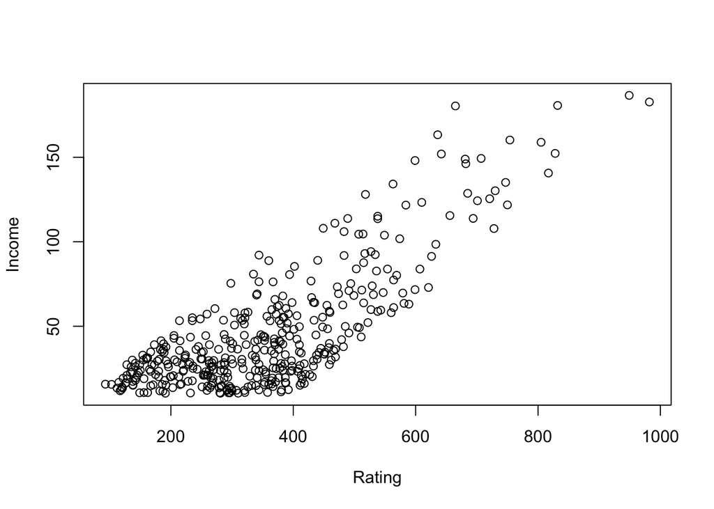

```r
plot(Credit[, c("Rating", "Income")])
```

# Model Fit

At the beginning, data Set has been spitted for testing and observation purposes.

```r
sample.size <- floor(0.80 * nrow(Credit)) # %80 for training, %20 for testing
train.index <- sample(seq_len(nrow(Credit)), size = sample.size)
train <- Credit[train.index, ]
test <- Credit[-train.index, ]
```

Superficial inference and relation between ‘Rating’ and ‘Income’ can be seen as correlation matrix. *Correlation Matrix :*

```r
cor(Credit[, c("Rating", "Income")])
```

```
##           Rating    Income
## Rating 1.0000000 0.7913776
## Income 0.7913776 1.0000000
```

## *Applying Linear Regression :*

```r
lm.fit = lm(Rating ~ Income, data = train)
summary(lm.fit)
```

```
##
## Call:
## lm(formula = Rating ~ Income, data = train)
##
## Residuals:
##      Min       1Q   Median       3Q      Max
## -172.014  -82.262   -0.364   81.302  173.870
##
## Coefficients:
##             Estimate Std. Error t value Pr(>|t|)
## (Intercept) 195.7658     8.7273   22.43   <2e-16 ***
## Income        3.4767     0.1526   22.78   <2e-16 ***
## ---
## Signif. codes:  0 '***' 0.001 '**' 0.01 '*' 0.05 '.' 0.1 ' ' 1
##
## Residual standard error: 96.35 on 318 degrees of freedom
## Multiple R-squared:   0.62,  Adjusted R-squared:  0.6188
## F-statistic: 518.8 on 1 and 318 DF,  p-value: < 2.2e-16
```

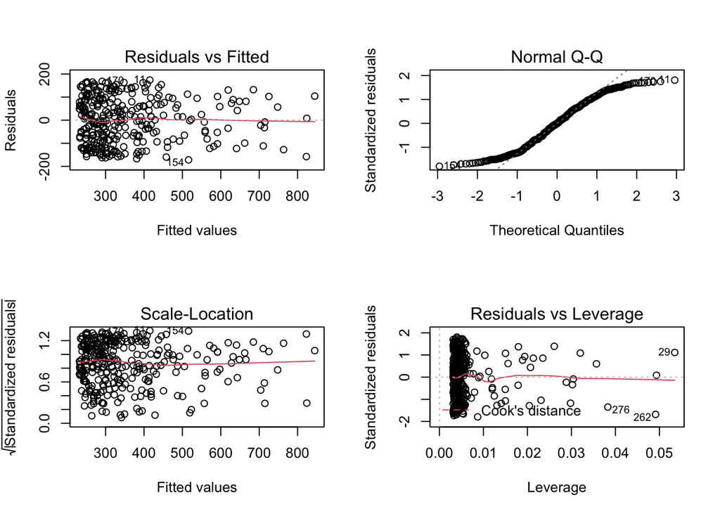

```r
par(mfrow = c(2,2))
plot(lm.fit)
```

*Scale-Location plot :* The residuals begin to spread wider at the beginning. However, The red line is roughly horizontal across the plot.Assumption of homoscedasticity is satisfied for a given regression model. So, the spread of the residuals is roughly equal.